# Гипертензия в Доминиканской республике

Команда №1: Ахметова Мария, Ильина Ирина, Кулиева Мария, Левченко Диана

2025-11-02

# 1. Загрузка данных и разделение пациентов на три группы в зависимости от тяжести гипертензии

```r
hypertension <- read_xlsx("data/originals/DominicanHTN_add_sign.xlsx")
hypertension <- hypertension %>%
  mutate(severity_hypertension = case_when(
    (SBP < 140 & DBP < 90) ~ "norm",
    ((SBP >= 140 & SBP < 160) | (DBP >= 90 & DBP < 100)) ~ "stage1",
    ((SBP >= 160 & SBP < 180) | (DBP >= 100 & DBP < 110)) ~ "stage2",
    (SBP >= 180 | DBP >= 110) ~ "stage3",
    TRUE ~ "crisis" ))

hypertension %>%
  filter(severity_hypertension == "crisis") #все пациенты распределены по группам
```

```
## # A tibble: 0 × 6
## # ℹ 6 variables: Village <chr>, Gender <chr>, Age <dbl>, SBP <dbl>, DBP <dbl>,
## #   severity_hypertension <chr>
```

# 2. Визуализация распределения значений признаков средствами ggplot2 и сопутствующих пакетов.

Проанализируем исходные данные.

Датасет состоит из 5 признаков:

- деревня (один из 8 вариантов)
- пол (мужской или женский)
- возраст (целое число)
- систолическое давление (целое число)
- диастолическое давление (целое число)

Пропущенных значений нет.

В представленном датасете женщин примерно в 2 раза больше, чем мужчин:

Распределение пациентов по полу

| Пол | Количество |
| --- | --- |
| Женский | 258 |
| Мужской | 123 |
| Всего | 381 |

Количественные признаки распределены неравномерно, их распределение у женщин и мужчин отличается. Особенно заметна разница в возрасте - для женщин медианный возраст составляет 43 года, для мужчин - 53.

[figure not shown]

Визуализируем зависимость систолического артериального давления (САД) и диастолического артериального давления (ДАД) от возраста для разных полов. ДАД имеет меньшие значения, меньший разброс и меньше зависит от возраста.

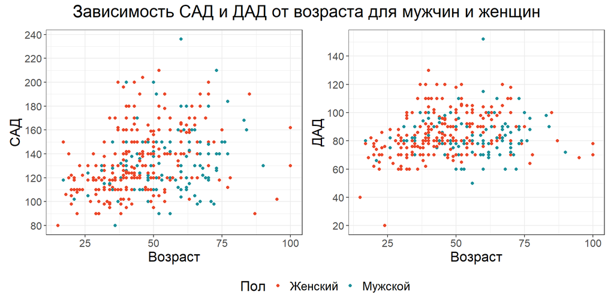

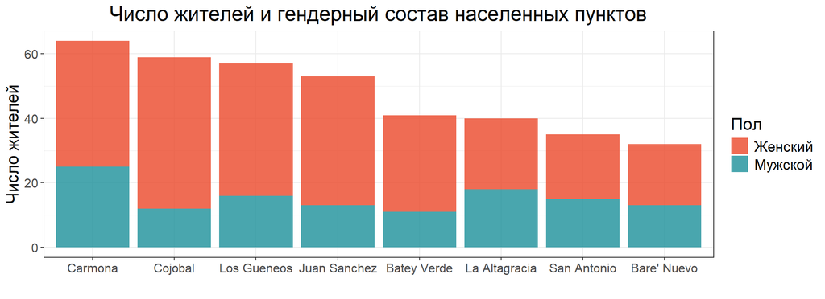

# 3. Подобрать и реализовать средства для визуальной оценки взаимосвязи между группой по гипертензии и собранными признаками пациентов.

## Распределение возраста по группам в зависимости от выраженности гипертензии

Построим график распределения возраста пациентов в зависимости от выраженности гипертензии в группах.

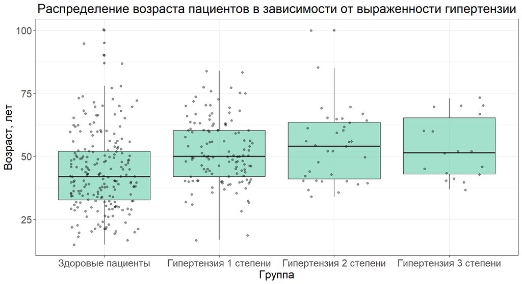

```r
scale_x_hypertension <- scale_x_discrete(name = "Группа",
                                         labels = c("norm" = "Здоровые пациенты",
                                                    "stage1" = "Гипертензия 1 степени",
                                                    "stage2" = "Гипертензия 2 степени",
                                                    "stage3" = "Гипертензия 3 степени"))

ggplot(hypertension, aes(x = severity_hypertension, y = Age)) +
  geom_boxplot(width = 0.8, alpha = 0.6, fill = "aquamarine3") +
  geom_jitter(width = 0.3, alpha = 0.4, color = "black") +
  labs(title = "Распределение возраста пациентов в зависимости от выраженности гипертензии",
       x = "Группа",
       y = "Возраст, лет")+
  scale_x_hypertension +
  theme_bw()+
  theme(
    plot.title = element_text(size = 19, hjust = 0.5),
    axis.title = element_text(size = 17),
    axis.text.y = element_text(size = 15),
    axis.text.x = element_text(size = 15)
  )
```

Рассмотрим данный график в зависимости от пола.

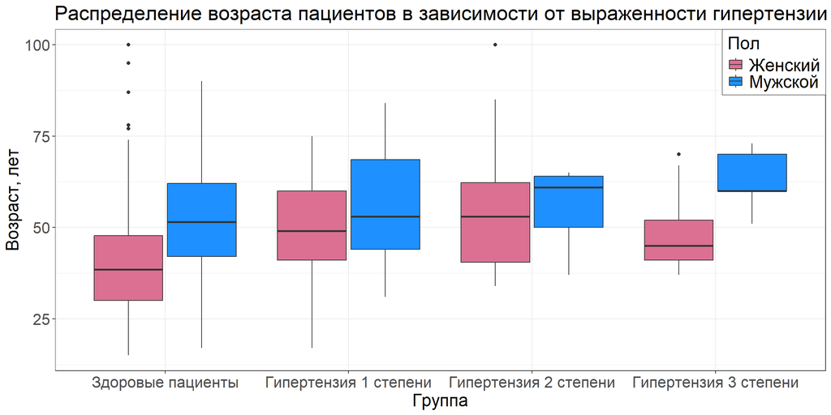

```r
scale_fill_gender <- scale_fill_manual(
    name = "Пол",
    labels = c(
      "Male" = "Мужской",
      "Female" = "Женский"),
    values = c(
      "Male" = "dodgerblue",
      "Female" = "palevioletred"))

ggplot(hypertension, aes(x = severity_hypertension, y = Age, fill = Gender)) +
  geom_boxplot(position = position_dodge(width = 0.8)) +
  labs(title = "Распределение возраста пациентов в зависимости от выраженности гипертензии",
       x = "Группа",
       y = "Возраст, лет")+
  scale_x_hypertension+
  scale_fill_gender+
  theme_bw()+
  theme(
    plot.title = element_text(size = 21, hjust = 0.2),
    axis.title = element_text(size = 18),
    axis.text.y = element_text(size = 16),
    axis.text.x = element_text(size = 16),
    legend.position = "inside",
    legend.justification = c("right", "top"),
    legend.title = element_text(size = 18),
    legend.text = element_text(size = 18),
    legend.background = element_rect(color = "black", size = 0.3)
  )
```

Видно, что средний возраст женщин в каждой из групп меньше, чем у мужчин.

## Распределение пола по группам в зависимости от выраженности гипертензии

Построим график распределения пола пациентов в зависимости от выраженности гипертензии в группах.

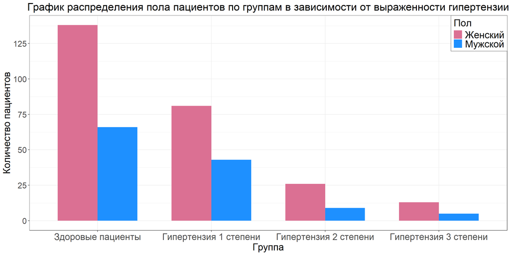

```r
ggplot(hypertension, aes(x = severity_hypertension, fill = Gender)) +
  geom_bar(position = "dodge", width = 0.7) +
  labs(title = "График распределения пола пациентов по группам в зависимости от выраженности гипертензии",
       x = "Группа",
       y = "Количество пациентов") +
  scale_x_hypertension +
  scale_y_continuous(
    name = "Количество пациентов",
    breaks = seq(0, 150, 25))+
  scale_fill_gender+
  theme_bw()+
  theme(
    plot.title = element_text(size = 21, hjust = 0.5),
    axis.title = element_text(size = 19),
    axis.text.y = element_text(size = 16),
    axis.text.x = element_text(size = 18),
    legend.position = "inside",
    legend.justification = c("right", "top"),
    legend.title = element_text(size = 19),
    legend.text = element_text(size = 19),
    legend.background = element_rect(color = "black", size = 0.3)
  )
```

Из графика видно, что женщин больше в каждой из групп. Также видно, что количество пациентов в каждой из групп снижается с повышением степени гипертензии.

## Распределение групп по деревням в зависимости от выраженности гипертензии

Построим график распределения групп по деревням.

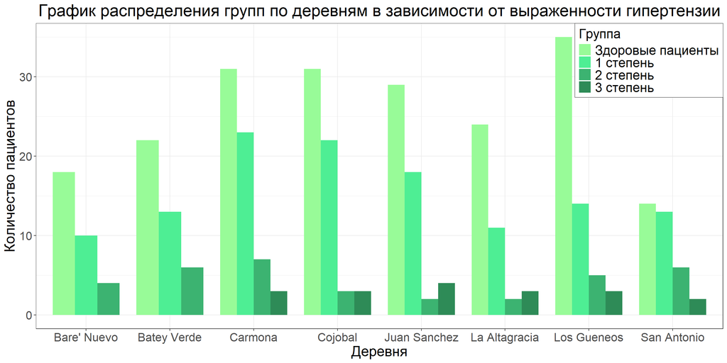

```r
scale_fill_hypertension <- scale_fill_manual(
    name = "Группа",
    labels = c(
      "norm" = "Здоровые пациенты",
      "stage1" = "1 степень",
      "stage2" = "2 степень",
      "stage3" = "3 степень"),
    values = c(
      "norm" = "palegreen",
      "stage1" = "seagreen2",
      "stage2" = "mediumseagreen",
      "stage3" = "seagreen"))

ggplot(hypertension, aes(x = Village, fill = severity_hypertension)) +
  geom_bar(position = "dodge", width = 0.8) +
  labs(title = "График распределения групп по деревням в зависимости от выраженности гипертензии",
       x = "Деревня", y = "Количество пациентов")+
  scale_fill_hypertension+
  theme_bw()+
  theme(
    plot.title = element_text(size = 23, hjust = 0.5),
    axis.title = element_text(size = 20),
    axis.text.y = element_text(size = 16),
    axis.text.x = element_text(size = 16),
    legend.position = "inside",
    legend.justification = c("right", "top"),
    legend.title = element_text(size = 18),
    legend.text = element_text(size = 18),
    legend.background = element_rect(color = "black", size = 0.3)
  )
```